# Exchange Curves: What a Portfolio Can Reach

Manuel D. Rossetti, PhD P.E.

## Agenda

- One item: investment times order frequency is fixed, and their ratio is $k/\gamma$
- What a chosen operating point implies about the costs
- Many items: the exchange curve, derived
- Reading a cost ratio from current practice
- Unequal ordering costs: the multiplier as a carrying charge, and the variety index
- A utility storeroom, traced

## One Item First

Let $\bar{I} = cQ/2$ represent the average investment and $\overline{\mathit{OF}} = \lambda/Q$ the order frequency. Let $\gamma$ represent a carrying charge shared by every item, written apart from $i$ to keep that assumption visible.

$$\begin{aligned}
\bar{I}\cdot\overline{\mathit{OF}} &= \frac{cQ}{2}\cdot\frac{\lambda}{Q} = \frac{c\lambda}{2}
&&\text{the order quantity cancels}\\
\frac{\bar{I}}{\overline{\mathit{OF}}} &= \frac{cQ^{*}}{2}\cdot\frac{Q^{*}}{\lambda} = \frac{c\,(Q^{*})^{2}}{2\lambda}
&&\text{at the economic order quantity}\\
&= \frac{c}{2\lambda}\cdot\frac{2k\lambda}{\gamma c} = \frac{k}{\gamma}
&&(Q^{*})^2 = 2k\lambda/(\gamma c)
\end{aligned}$$

The **product** fixes a hyperbola from the item’s own data, and the **ratio** fixes the point on it. The ratio is $k/\gamma$, and nothing else about the item enters.

Ordering more often is not a policy that can be adopted on its own. It is the same policy as holding less stock.

## What a Chosen Operating Point Implies

A planner orders an item twice a year and carries an average of $400 of it:

$$\begin{aligned}
\frac{\bar{I}}{\overline{\mathit{OF}}} &= \frac{400}{2} = 200 = \frac{k}{\gamma}
&&\text{the planner's practice}\\
k &= 200\gamma = 200(0.20) = \$40
&&\text{implied, at } \gamma = 0.20
\end{aligned}$$

That number can be checked, and the check is the point. Purchasing reports that an order costs $120, so the ratio should be $120/0.20 = 600$; the planner operates at 200, ordering far too often for the stated carrying charge.

Read it the other way: if the practice is correct, then $\gamma = k/200 = 120/200 = 0.60$, a carrying charge of **60%** a year.

One of two things is true: the item is ordered too often, or the firm’s carrying charge is three times what it says. The calculation does not settle which, but it forces somebody to make one of the claims.

## Now Take Many Items

Let $\bar{I}^{a} = \sum_j c_jQ_j/2$ represent the **aggregate investment in cycle stock** and $N^{a} = \sum_j \lambda_j/Q_j$ the **aggregate number of replenishments**. With a common $k$ and $\gamma$, put each $Q_j = \sqrt{2k\lambda_j/(\gamma c_j)}$ into one item’s terms:

$$\begin{aligned}
c_j\frac{Q_j}{2} &= \frac{c_j}{2}\sqrt{\frac{2k\lambda_j}{\gamma c_j}} = \sqrt{\frac{k}{\gamma}}\cdot\frac{\sqrt{\lambda_jc_j}}{\sqrt{2}}
&&\text{move $c_j/2$ inside the root}\\
\frac{\lambda_j}{Q_j} &= \lambda_j\sqrt{\frac{\gamma c_j}{2k\lambda_j}} = \sqrt{\frac{\gamma}{k}}\cdot\frac{\sqrt{\lambda_jc_j}}{\sqrt{2}}
&&\text{move $\lambda_j$ inside the root}
\end{aligned}$$

Every item carries the same factor, $\sqrt{k/\gamma}$ or $\sqrt{\gamma/k}$, so the sums factor too.

## The Product, and the Ratio

Sum each line over the items, then multiply and divide:

$$\begin{aligned}
\bar{I}^{a}\cdot N^{a} &= \sqrt{\frac{k}{\gamma}}\sqrt{\frac{\gamma}{k}}\cdot\frac{1}{2}\Big(\sum_j\sqrt{\lambda_jc_j}\Big)^{2} = \frac{1}{2}\Big(\sum_j\sqrt{\lambda_jc_j}\Big)^{2}
&&\text{sum, then multiply}\\
\frac{\bar{I}^{a}}{N^{a}} &= \sqrt{\frac{k}{\gamma}}\Big/\sqrt{\frac{\gamma}{k}} = \frac{k}{\gamma}
&&\text{sum, then divide}
\end{aligned}$$

These are the one-item results again, one level up. The product depends on the item data alone, and defines a single hyperbola, the **exchange curve**. The ratio $k/\gamma$ is a ray from the origin, and where the ray crosses the curve is where the portfolio operates.

## The Curve

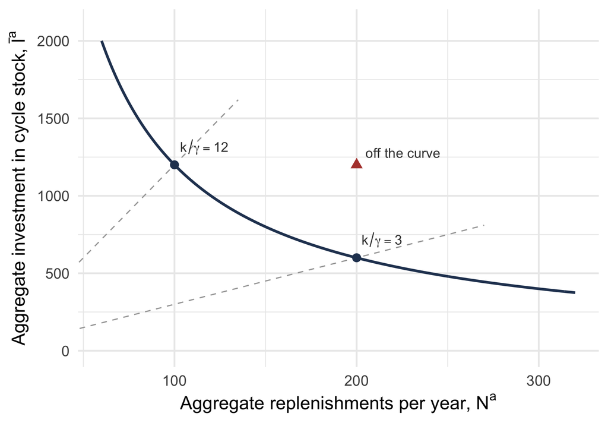

The solid curve is $\bar{I}^{a}N^{a} = 120{,}000$. Investment falls as replenishments rise, and the curve flattens: each additional order gives up less stock than the last.

The dashed rays are cost ratios. $k/\gamma = 12$ meets the curve at 100 orders and $1,200; $k/\gamma = 3$ at 200 orders and $600.

Notice that a firm does not choose a point on the curve. It chooses a cost ratio, and the ratio chooses the point.

The triangle, 200 orders against $1,200, has product 240,000. No set of economic quantities produces it.

## Reading It Backwards

The curve is more useful read backwards: observe a point and ask what it implies.

**A point off the curve means the quantities are not economic.** For any number of orders no policy holds less stock, and for any stock none orders less often. A portfolio above the curve can move onto it and improve **both** measures at once, with no trade-off to argue about and no new money.

**A point on the curve reveals a cost ratio,** $\bar{I}^{a}/N^{a} = k/\gamma$. Compared against the firm’s actual $k$ and $\gamma$, a discrepancy says current practice is optimal for costs the firm does not have.

Moving a portfolio onto its curve is the rare case in which an inventory recommendation costs nothing.

## What Current Practice Implies

A distributor places 100 orders a year across a group and carries $1,200 of cycle stock, on its curve: $\bar{I}^{a}/N^{a} = 1{,}200/100 = 12 = k/\gamma$.

*Case 1, the ordering cost is known.* Cost estimation puts $k = \$4$:

$$\begin{aligned}
\gamma &= k/12 = 4/12 = 0.333 \text{ per year}
&&\text{what makes practice optimal}\\
k/\gamma &= 4/0.20 = 20 \ne 12
&&\text{if the true charge is } 20\%
\end{aligned}$$

At 20% the firm is ordering too often for the stock it holds, and should move along the curve toward fewer orders and more stock.

*Case 2, neither is known.* The ratio is still what the firm’s behavior asserts. A manager who rejects $k/\gamma = 12$ as absurd has learned something about current practice.

*Case 3, the point is constrained.* If transportation fixes 200 orders a year, the curve gives $600 and requires $k/\gamma = 3$. Since $\gamma$ is the cost of capital, reaching that means **reducing $k$**: the curve says which cost to attack.

## When Ordering Costs Differ

An item from overseas and one from a local supplier do not cost the same to order. Let $\overline{\mathit{OC}}^{a} = \sum_j k_j\lambda_j/Q_j$ represent the aggregate ordering **cost** rate, and minimize it for a fixed investment:

$$\begin{aligned}
\min \sum_j \frac{k_j\lambda_j}{Q_j} \quad &\text{s.t.} \quad \sum_j \frac{c_jQ_j}{2} = \bar{I}^{a}
&&\text{no holding cost in the objective}\\
-\frac{k_j\lambda_j}{Q_j^{2}} + \frac{\theta c_j}{2} &= 0
&&\text{differentiate the Lagrangian}\\
Q_j &= \sqrt{\frac{2k_j\lambda_j}{c_j\theta}}
&&\text{the multiplier replaces the carrying charge}
\end{aligned}$$

The same symbol has now carried three meanings, and the formulation decides which: added to the holding rate under a limit on stock, added to the ordering cost under a limit on replenishments, and **standing in for the carrying charge** when there is no holding cost at all. Here it is the implied carrying charge read from practice.

## The General Curve

Substitute $Q_j = \sqrt{2k_j\lambda_j/(c_j\theta)}$ into both aggregates:

$$\begin{aligned}
\bar{I}^{a} &= \sum_j \frac{c_j}{2}\sqrt{\frac{2k_j\lambda_j}{c_j\theta}} = \frac{1}{\sqrt{2\theta}}\sum_j\sqrt{k_jc_j\lambda_j}
&&\text{investment}\\
\overline{\mathit{OC}}^{a} &= \sum_j k_j\lambda_j\sqrt{\frac{c_j\theta}{2k_j\lambda_j}} = \sqrt{\frac{\theta}{2}}\sum_j\sqrt{k_jc_j\lambda_j}
&&\text{ordering cost}\\
\bar{I}^{a}\cdot\overline{\mathit{OC}}^{a} &= \frac{1}{2}\Big(\sum_j\sqrt{k_jc_j\lambda_j}\Big)^{2}
&&\text{$\theta$ cancels}\\
\bar{I}^{a}/\overline{\mathit{OC}}^{a} &= 1/\theta
&&\text{$\theta$ picks the point}
\end{aligned}$$

The same structure survives, with $\lambda_jc_j$ replaced by $k_jc_j\lambda_j$ and the order count by the order cost. Varying $\theta$ traces the curve.

## A Utility Storeroom

Order handling costs $\kappa = \$55$ an hour and item $j$ takes $w_j$ hours, so $k_j = \kappa w_j$; $\gamma = 0.25$.

| Item | $\lambda_j$ | $c_j$ | $w_j$ | $k_j$ | $\sqrt{k_j c_j\lambda_j}$ |
| --- | --- | --- | --- | --- | --- |
| Pad-mount transformer | 45 | $3,800.00 | 4 | $220.00 | 6,133.51 |
| Smart meter | 1,200 | $95.00 | 2 | $110.00 | 3,541.19 |
| Fuse cutout | 800 | $115.00 | 1.5 | $82.50 | 2,755.00 |
| Meter socket | 900 | $48.00 | 1.5 | $82.50 | 1,887.86 |
| Riser conduit, 4 in | 600 | $62.00 | 1.5 | $82.50 | 1,751.86 |
| Splice kit | 1,500 | $28.00 | 1 | $55.00 | 1,519.87 |
| Ground rod | 2,400 | $14.00 | 0.75 | $41.25 | 1,177.29 |
| Compression connector | 6,000 | $3.40 | 0.5 | $27.50 | 749.00 |
| Warning tape, roll | 1,000 | $2.10 | 0.5 | $27.50 | 240.31 |
| **Total** |  |  |  |  | **19,755.87** |

The curve: $\bar{I}^{a}\cdot\overline{\mathit{OC}}^{a} = \tfrac{1}{2}(19{,}755.87)^{2} = 1.951\times 10^{8}$.

## Tracing It With the Multiplier

| $\theta$ | $\bar{I}^{a} = 19{,}755.87/\sqrt{2\theta}$ | $\overline{\mathit{OC}}^{a} = \sqrt{\theta/2}\,(19{,}755.87)$ | Order handling, $\overline{\mathit{OC}}^{a}/55$ | Product |
| --- | --- | --- | --- | --- |
| 0.05 | $62,474 | $3,124 | 57 hours | $1.951\times 10^{8}$ |
| 0.10 | $44,175 | $4,418 | 80 hours | $1.951\times 10^{8}$ |
| **0.25** | **$27,939** | **$6,985** | **127 hours** | $1.951\times 10^{8}$ |
| 0.50 | $19,756 | $9,878 | 180 hours | $1.951\times 10^{8}$ |
| 1.00 | $13,970 | $13,970 | 254 hours | $1.951\times 10^{8}$ |

*The check:* the product column is constant, and checking it is the arithmetic check for this section.

The firm’s own carrying charge is the multiplier, so $\theta = \gamma = 0.25$ puts the storeroom on the third row: $27,939 of cycle stock against $6,985 a year of order handling, 127 hours of a storekeeper’s time. Since $\bar{I}^{a}/\overline{\mathit{OC}}^{a} = 1/\theta = 4$, it holds four dollars of stock for every dollar a year it spends on ordering.

## The Variety Index

Let $J^{*}$ represent the **variety index**:

$$J^{*} = \frac{\left(\sum_j\sqrt{k_j c_j\lambda_j}\right)^{2}}{\sum_j k_j c_j\lambda_j},
\qquad 1 \le J^{*} \le n,
\qquad
\bar{I}^{a}\cdot\overline{\mathit{OC}}^{a} = \frac{1}{2}J^{*}\sum_j k_j c_j\lambda_j .$$

If every item contributes equally, $J^{*} = n$; if one item dominates, $J^{*}$ approaches 1. It is the **effective** number of items: a portfolio with index $J^{*}$ behaves in aggregate like $J^{*}$ identical ones.

For the storeroom the nine products under the square roots total $\sum_j k_jc_j\lambda_j = 68{,}697{,}750$, of which the transformer’s is 37,620,000:

$$J^{*} = \frac{(19{,}755.87)^{2}}{68{,}697{,}750} = \frac{390{,}294{,}400}{68{,}697{,}750} = 5.68 .$$

Nine items behave like fewer than six identical ones. The transformer alone contributes 6,133 of the 19,756 in the last column.

## What Moves the Whole Curve

Let $C^{a} = \sum_j c_j\lambda_j$ represent the aggregate purchase cost rate and $\lambda^{a} = \sum_j\lambda_j$ the aggregate demand rate. Then

$$\begin{aligned}
K^{w} &= \sum_j \frac{c_j\lambda_j}{C^{a}}\,k_j, \qquad c^{w} = \frac{C^{a}}{\lambda^{a}}
&&\text{two weighted averages}\\
\sum_j k_jc_j\lambda_j &= K^{w}C^{a} = K^{w}\lambda^{a}c^{w}
&&\text{definitions of } K^{w}, c^{w}\\
\bar{I}^{a}\cdot\overline{\mathit{OC}}^{a} &= \tfrac{1}{2}J^{*}K^{w}\lambda^{a}c^{w}
&&\text{four things set the frontier}\\
c^{w} &= 555{,}500/14{,}445 = \$38.4562
&&\text{the storeroom's typical unit}\\
K^{w} &= 68{,}697{,}750/555{,}500 = \$123.668
&&\text{its typical order}\\
&= \tfrac{1}{2}(5.6813)(123.668)(14{,}445)(38.4562) = 1.951\times 10^{8}
&&\text{the same constant}
\end{aligned}$$

Each of the four is something a firm can act on. **Reducing the cost of placing an order shifts the entire frontier inward**, which is the quantitative argument for simplifying purchasing.

## What We Did Today

**For one item, investment times order frequency is $c\lambda/2$,** whatever $Q$, and their ratio at the economic quantity is $k/\gamma$.

**For many items the product is fixed by the data:** that is the exchange curve, and the cost ratio picks the point.

**Read backwards,** a point off the curve can improve both measures at no cost, and a point on it reveals the $k/\gamma$ practice implies.

**With unequal ordering costs the multiplier stands in for the carrying charge,** the product is $\frac{1}{2}(\sum_j\sqrt{k_jc_j\lambda_j})^2$, and varying $\theta$ traces the curve.

## For Next Time

**Read before next session:** *Joint Replenishment*.

Today’s material was *The Exchange Curve*.

Next session:

- The second coupling: items that share part of the cost of an order
- A common cycle, integer ratios, and power-of-two policies
- Why a power-of-two policy costs at most 6.07% more, derived
- Four items from one supplier, coordinated

Recall the flatness of the economic order quantity’s cost curve. Next session it is what licenses rounding cycle lengths to powers of two.

⌂ Index